# Risk Factor Analysis

## Outcome Variable

**Outcome Variable:** stunted

## Predictor Variables

**Intervention Variable:** enstunt

**Adjustment Set:**

unadjusted

## Stratifying Variables

The analysis was stratified on these variable(s):

- agecat
- studyid
- country

## Data Summary

| agecat | studyid | country | enstunt | stunted | n_cell | n |
| --- | --- | --- | --- | --- | --- | --- |
| Birth | ki0047075b-MAL-ED | BANGLADESH | 0 | 0 | 210 | 257 |
| Birth | ki0047075b-MAL-ED | BANGLADESH | 0 | 1 | 0 | 257 |
| Birth | ki0047075b-MAL-ED | BANGLADESH | 1 | 0 | 0 | 257 |
| Birth | ki0047075b-MAL-ED | BANGLADESH | 1 | 1 | 47 | 257 |
| 6 months | ki0047075b-MAL-ED | BANGLADESH | 0 | 0 | 174 | 233 |
| 6 months | ki0047075b-MAL-ED | BANGLADESH | 0 | 1 | 21 | 233 |
| 6 months | ki0047075b-MAL-ED | BANGLADESH | 1 | 0 | 16 | 233 |
| 6 months | ki0047075b-MAL-ED | BANGLADESH | 1 | 1 | 22 | 233 |
| 24 months | ki0047075b-MAL-ED | BANGLADESH | 0 | 0 | 105 | 206 |
| 24 months | ki0047075b-MAL-ED | BANGLADESH | 0 | 1 | 69 | 206 |
| 24 months | ki0047075b-MAL-ED | BANGLADESH | 1 | 0 | 8 | 206 |
| 24 months | ki0047075b-MAL-ED | BANGLADESH | 1 | 1 | 24 | 206 |
| Birth | ki0047075b-MAL-ED | BRAZIL | 0 | 0 | 170 | 191 |
| Birth | ki0047075b-MAL-ED | BRAZIL | 0 | 1 | 0 | 191 |
| Birth | ki0047075b-MAL-ED | BRAZIL | 1 | 0 | 0 | 191 |
| Birth | ki0047075b-MAL-ED | BRAZIL | 1 | 1 | 21 | 191 |
| 6 months | ki0047075b-MAL-ED | BRAZIL | 0 | 0 | 153 | 173 |
| 6 months | ki0047075b-MAL-ED | BRAZIL | 0 | 1 | 3 | 173 |
| 6 months | ki0047075b-MAL-ED | BRAZIL | 1 | 0 | 16 | 173 |
| 6 months | ki0047075b-MAL-ED | BRAZIL | 1 | 1 | 1 | 173 |
| 24 months | ki0047075b-MAL-ED | BRAZIL | 0 | 0 | 121 | 139 |
| 24 months | ki0047075b-MAL-ED | BRAZIL | 0 | 1 | 5 | 139 |
| 24 months | ki0047075b-MAL-ED | BRAZIL | 1 | 0 | 12 | 139 |
| 24 months | ki0047075b-MAL-ED | BRAZIL | 1 | 1 | 1 | 139 |
| Birth | ki0047075b-MAL-ED | INDIA | 0 | 0 | 173 | 206 |
| Birth | ki0047075b-MAL-ED | INDIA | 0 | 1 | 0 | 206 |
| Birth | ki0047075b-MAL-ED | INDIA | 1 | 0 | 0 | 206 |
| Birth | ki0047075b-MAL-ED | INDIA | 1 | 1 | 33 | 206 |
| 6 months | ki0047075b-MAL-ED | INDIA | 0 | 0 | 137 | 192 |
| 6 months | ki0047075b-MAL-ED | INDIA | 0 | 1 | 25 | 192 |

[output cut: 288 more lines]

The following strata were considered:

- agecat: 24 months, studyid: ki0047075b-MAL-ED, country: BANGLADESH
- agecat: 24 months, studyid: ki0047075b-MAL-ED, country: BRAZIL
- agecat: 24 months, studyid: ki0047075b-MAL-ED, country: INDIA
- agecat: 24 months, studyid: ki0047075b-MAL-ED, country: NEPAL
- agecat: 24 months, studyid: ki0047075b-MAL-ED, country: PERU
- agecat: 24 months, studyid: ki0047075b-MAL-ED, country: SOUTH AFRICA
- agecat: 24 months, studyid: ki0047075b-MAL-ED, country: TANZANIA, UNITED REPUBLIC OF
- agecat: 24 months, studyid: ki1000108-CMC-V-BCS-2002, country: INDIA
- agecat: 24 months, studyid: ki1000108-IRC, country: INDIA
- agecat: 24 months, studyid: ki1017093-NIH-Birth, country: BANGLADESH
- agecat: 24 months, studyid: ki1017093c-NIH-Crypto, country: BANGLADESH
- agecat: 24 months, studyid: ki1101329-Keneba, country: GAMBIA
- agecat: 24 months, studyid: ki1113344-GMS-Nepal, country: NEPAL
- agecat: 24 months, studyid: ki1114097-CMIN, country: GUINEA-BISSAU
- agecat: 24 months, studyid: ki1114097-CMIN, country: PERU
- agecat: 24 months, studyid: ki1114097-CONTENT, country: PERU
- agecat: 24 months, studyid: ki1119695-PROBIT, country: BELARUS
- agecat: 24 months, studyid: ki1126311-ZVITAMBO, country: ZIMBABWE
- agecat: 24 months, studyid: ki1135781-COHORTS, country: GUATEMALA
- agecat: 24 months, studyid: ki1135781-COHORTS, country: INDIA
- agecat: 24 months, studyid: ki1135781-COHORTS, country: PHILIPPINES
- agecat: 24 months, studyid: ki1148112-LCNI-5, country: MALAWI
- agecat: 24 months, studyid: kiGH5241-JiVitA-3, country: BANGLADESH
- agecat: 24 months, studyid: kiGH5241-JiVitA-4, country: BANGLADESH
- agecat: 6 months, studyid: ki0047075b-MAL-ED, country: BANGLADESH
- agecat: 6 months, studyid: ki0047075b-MAL-ED, country: BRAZIL
- agecat: 6 months, studyid: ki0047075b-MAL-ED, country: INDIA
- agecat: 6 months, studyid: ki0047075b-MAL-ED, country: NEPAL
- agecat: 6 months, studyid: ki0047075b-MAL-ED, country: PERU
- agecat: 6 months, studyid: ki0047075b-MAL-ED, country: SOUTH AFRICA
- agecat: 6 months, studyid: ki0047075b-MAL-ED, country: TANZANIA, UNITED REPUBLIC OF
- agecat: 6 months, studyid: ki1000108-CMC-V-BCS-2002, country: INDIA
- agecat: 6 months, studyid: ki1000108-IRC, country: INDIA
- agecat: 6 months, studyid: ki1000109-EE, country: PAKISTAN
- agecat: 6 months, studyid: ki1000109-ResPak, country: PAKISTAN
- agecat: 6 months, studyid: ki1000304b-SAS-CompFeed, country: INDIA
- agecat: 6 months, studyid: ki1000304b-SAS-FoodSuppl, country: INDIA
- agecat: 6 months, studyid: ki1017093-NIH-Birth, country: BANGLADESH
- agecat: 6 months, studyid: ki1017093c-NIH-Crypto, country: BANGLADESH
- agecat: 6 months, studyid: ki1066203-TanzaniaChild2, country: TANZANIA, UNITED REPUBLIC OF
- agecat: 6 months, studyid: ki1101329-Keneba, country: GAMBIA
- agecat: 6 months, studyid: ki1112895-Guatemala BSC, country: GUATEMALA
- agecat: 6 months, studyid: ki1113344-GMS-Nepal, country: NEPAL
- agecat: 6 months, studyid: ki1114097-CMIN, country: BRAZIL
- agecat: 6 months, studyid: ki1114097-CMIN, country: GUINEA-BISSAU
- agecat: 6 months, studyid: ki1114097-CMIN, country: PERU
- agecat: 6 months, studyid: ki1114097-CONTENT, country: PERU
- agecat: 6 months, studyid: ki1119695-PROBIT, country: BELARUS
- agecat: 6 months, studyid: ki1126311-ZVITAMBO, country: ZIMBABWE
- agecat: 6 months, studyid: ki1135781-COHORTS, country: GUATEMALA
- agecat: 6 months, studyid: ki1135781-COHORTS, country: INDIA
- agecat: 6 months, studyid: ki1135781-COHORTS, country: PHILIPPINES
- agecat: 6 months, studyid: ki1148112-LCNI-5, country: MALAWI
- agecat: 6 months, studyid: kiGH5241-JiVitA-3, country: BANGLADESH
- agecat: 6 months, studyid: kiGH5241-JiVitA-4, country: BANGLADESH
- agecat: Birth, studyid: ki0047075b-MAL-ED, country: BANGLADESH
- agecat: Birth, studyid: ki0047075b-MAL-ED, country: BRAZIL
- agecat: Birth, studyid: ki0047075b-MAL-ED, country: INDIA
- agecat: Birth, studyid: ki0047075b-MAL-ED, country: NEPAL
- agecat: Birth, studyid: ki0047075b-MAL-ED, country: PERU
- agecat: Birth, studyid: ki0047075b-MAL-ED, country: SOUTH AFRICA
- agecat: Birth, studyid: ki0047075b-MAL-ED, country: TANZANIA, UNITED REPUBLIC OF
- agecat: Birth, studyid: ki1000108-CMC-V-BCS-2002, country: INDIA
- agecat: Birth, studyid: ki1000108-IRC, country: INDIA
- agecat: Birth, studyid: ki1000109-EE, country: PAKISTAN
- agecat: Birth, studyid: ki1000109-ResPak, country: PAKISTAN
- agecat: Birth, studyid: ki1000304b-SAS-CompFeed, country: INDIA
- agecat: Birth, studyid: ki1017093-NIH-Birth, country: BANGLADESH
- agecat: Birth, studyid: ki1017093c-NIH-Crypto, country: BANGLADESH
- agecat: Birth, studyid: ki1101329-Keneba, country: GAMBIA
- agecat: Birth, studyid: ki1114097-CMIN, country: BANGLADESH
- agecat: Birth, studyid: ki1114097-CMIN, country: BRAZIL
- agecat: Birth, studyid: ki1114097-CMIN, country: PERU
- agecat: Birth, studyid: ki1114097-CONTENT, country: PERU
- agecat: Birth, studyid: ki1119695-PROBIT, country: BELARUS
- agecat: Birth, studyid: ki1126311-ZVITAMBO, country: ZIMBABWE
- agecat: Birth, studyid: ki1135781-COHORTS, country: GUATEMALA
- agecat: Birth, studyid: ki1135781-COHORTS, country: INDIA
- agecat: Birth, studyid: ki1135781-COHORTS, country: PHILIPPINES
- agecat: Birth, studyid: kiGH5241-JiVitA-3, country: BANGLADESH
- agecat: Birth, studyid: kiGH5241-JiVitA-4, country: BANGLADESH

### Dropped Strata

Some strata were dropped due to rare outcomes:

- agecat: Birth, studyid: ki0047075b-MAL-ED, country: BANGLADESH
- agecat: Birth, studyid: ki0047075b-MAL-ED, country: BRAZIL
- agecat: 6 months, studyid: ki0047075b-MAL-ED, country: BRAZIL
- agecat: 24 months, studyid: ki0047075b-MAL-ED, country: BRAZIL
- agecat: Birth, studyid: ki0047075b-MAL-ED, country: INDIA
- agecat: Birth, studyid: ki0047075b-MAL-ED, country: NEPAL
- agecat: 6 months, studyid: ki0047075b-MAL-ED, country: NEPAL
- agecat: Birth, studyid: ki0047075b-MAL-ED, country: PERU
- agecat: Birth, studyid: ki0047075b-MAL-ED, country: SOUTH AFRICA
- agecat: Birth, studyid: ki0047075b-MAL-ED, country: TANZANIA, UNITED REPUBLIC OF
- agecat: 6 months, studyid: ki0047075b-MAL-ED, country: TANZANIA, UNITED REPUBLIC OF
- agecat: 24 months, studyid: ki0047075b-MAL-ED, country: TANZANIA, UNITED REPUBLIC OF
- agecat: Birth, studyid: ki1000108-CMC-V-BCS-2002, country: INDIA
- agecat: Birth, studyid: ki1000108-IRC, country: INDIA
- agecat: 6 months, studyid: ki1000109-EE, country: PAKISTAN
- agecat: Birth, studyid: ki1000109-EE, country: PAKISTAN
- agecat: Birth, studyid: ki1000109-ResPak, country: PAKISTAN
- agecat: Birth, studyid: ki1000304b-SAS-CompFeed, country: INDIA
- agecat: Birth, studyid: ki1017093-NIH-Birth, country: BANGLADESH
- agecat: Birth, studyid: ki1017093c-NIH-Crypto, country: BANGLADESH
- agecat: 6 months, studyid: ki1017093c-NIH-Crypto, country: BANGLADESH
- agecat: 24 months, studyid: ki1017093c-NIH-Crypto, country: BANGLADESH
- agecat: 6 months, studyid: ki1066203-TanzaniaChild2, country: TANZANIA, UNITED REPUBLIC OF
- agecat: Birth, studyid: ki1101329-Keneba, country: GAMBIA
- agecat: 6 months, studyid: ki1113344-GMS-Nepal, country: NEPAL
- agecat: 24 months, studyid: ki1113344-GMS-Nepal, country: NEPAL
- agecat: Birth, studyid: ki1114097-CMIN, country: BANGLADESH
- agecat: Birth, studyid: ki1114097-CMIN, country: BRAZIL
- agecat: 6 months, studyid: ki1114097-CMIN, country: BRAZIL
- agecat: 24 months, studyid: ki1114097-CMIN, country: GUINEA-BISSAU
- agecat: 6 months, studyid: ki1114097-CMIN, country: PERU
- agecat: 24 months, studyid: ki1114097-CMIN, country: PERU
- agecat: 6 months, studyid: ki1114097-CONTENT, country: PERU
- agecat: 24 months, studyid: ki1114097-CONTENT, country: PERU
- agecat: Birth, studyid: ki1114097-CONTENT, country: PERU
- agecat: Birth, studyid: ki1119695-PROBIT, country: BELARUS
- agecat: 24 months, studyid: ki1119695-PROBIT, country: BELARUS
- agecat: Birth, studyid: ki1126311-ZVITAMBO, country: ZIMBABWE
- agecat: Birth, studyid: ki1135781-COHORTS, country: GUATEMALA
- agecat: Birth, studyid: ki1135781-COHORTS, country: INDIA
- agecat: Birth, studyid: ki1135781-COHORTS, country: PHILIPPINES
- agecat: 6 months, studyid: ki1148112-LCNI-5, country: MALAWI
- agecat: Birth, studyid: kiGH5241-JiVitA-3, country: BANGLADESH
- agecat: Birth, studyid: kiGH5241-JiVitA-4, country: BANGLADESH

## Methods Detail

We’re interested in the causal parameters $E[Y_a]$ for all values of $a \in \mathcal{A}$. These parameters represent the mean outcome if, possibly contrary to fact, we intervened to set all units to have $A=a$. Under the randomization and positivity assumptions, these are identified by the statistical parameters $\psi_a=E_W[E_{Y|A,W}(Y|A=a,W)]$. In addition, we’re interested in the mean of $Y$, $E[Y]$ under no intervention (the observed mean). We will estimate these parameters by using SuperLearner to fit the relevant likelihood factors – $E_{Y|A,W}(Y|A=a,W)$ and $p(A=a|W)$, and then updating our likelihood fit using a joint TMLE.

For unadjusted analyses ($W=\{\}$), initial likelihoods were estimated using Lrnr_glm to estimate the simple $E(Y|A)$ and Lrnr_mean to estimate $p(A)$. For adjusted analyses, a small library containing Lrnr_glmnet, Lrnr_xgboost, and Lrnr_mean was used.

Having estimated these parameters, we will then use the delta method to estimate relative risks and attributable risks relative to a prespecified baseline level of $A$.

[output not shown]

# Results Detail

## Results Plots

[figure not shown]

[figure not shown]

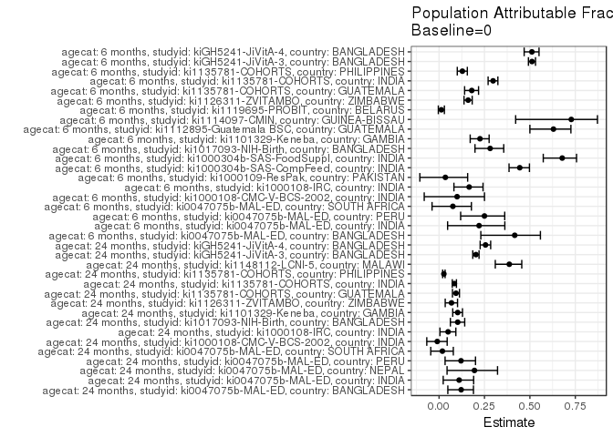

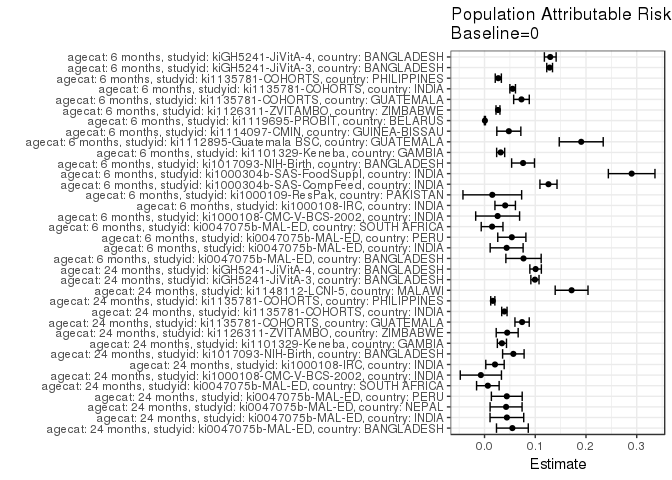

## Results Table

### Parameter: TSM

| agecat | studyid | country | intervention_level | baseline_level | estimate | ci_lower | ci_upper |
| --- | --- | --- | --- | --- | --- | --- | --- |
| 6 months | ki0047075b-MAL-ED | BANGLADESH | 0 | NA | 0.1076923 | 0.0640895 | 0.1512951 |
| 6 months | ki0047075b-MAL-ED | BANGLADESH | 1 | NA | 0.5789474 | 0.4216295 | 0.7362652 |
| 6 months | ki0047075b-MAL-ED | INDIA | 0 | NA | 0.1543210 | 0.0985460 | 0.2100960 |
| 6 months | ki0047075b-MAL-ED | INDIA | 1 | NA | 0.4333333 | 0.2555479 | 0.6111188 |
| 6 months | ki0047075b-MAL-ED | PERU | 0 | NA | 0.1615721 | 0.1138100 | 0.2093341 |
| 6 months | ki0047075b-MAL-ED | PERU | 1 | NA | 0.6129032 | 0.4411085 | 0.7846979 |
| 6 months | ki0047075b-MAL-ED | SOUTH AFRICA | 0 | NA | 0.1813472 | 0.1268603 | 0.2358340 |
| 6 months | ki0047075b-MAL-ED | SOUTH AFRICA | 1 | NA | 0.3333333 | 0.1312413 | 0.5354254 |
| 6 months | ki1000108-CMC-V-BCS-2002 | INDIA | 0 | NA | 0.2345679 | 0.1418066 | 0.3273292 |
| 6 months | ki1000108-CMC-V-BCS-2002 | INDIA | 1 | NA | 0.4000000 | 0.1507806 | 0.6492194 |
| 6 months | ki1000108-IRC | INDIA | 0 | NA | 0.2049861 | 0.1632917 | 0.2466806 |
| 6 months | ki1000108-IRC | INDIA | 1 | NA | 0.5652174 | 0.4217850 | 0.7086498 |
| 6 months | ki1000109-ResPak | PAKISTAN | 0 | NA | 0.4262295 | 0.3013151 | 0.5511439 |
| 6 months | ki1000109-ResPak | PAKISTAN | 1 | NA | 0.5000000 | 0.2533980 | 0.7466020 |
| 6 months | ki1000304b-SAS-CompFeed | INDIA | 0 | NA | 0.1577320 | 0.1379891 | 0.1774748 |
| 6 months | ki1000304b-SAS-CompFeed | INDIA | 1 | NA | 0.6215470 | 0.5852907 | 0.6578033 |
| 6 months | ki1000304b-SAS-FoodSuppl | INDIA | 0 | NA | 0.1377778 | 0.0926807 | 0.1828749 |
| 6 months | ki1000304b-SAS-FoodSuppl | INDIA | 1 | NA | 0.8873239 | 0.8352461 | 0.9394018 |
| 6 months | ki1017093-NIH-Birth | BANGLADESH | 0 | NA | 0.1941964 | 0.1575314 | 0.2308615 |
| 6 months | ki1017093-NIH-Birth | BANGLADESH | 1 | NA | 0.6705882 | 0.5705781 | 0.7705984 |
| 6 months | ki1101329-Keneba | GAMBIA | 0 | NA | 0.1094659 | 0.0953902 | 0.1235416 |
| 6 months | ki1101329-Keneba | GAMBIA | 1 | NA | 0.4467005 | 0.3772609 | 0.5161401 |
| 6 months | ki1112895-Guatemala BSC | GUATEMALA | 0 | NA | 0.1121076 | 0.0706281 | 0.1535871 |
| 6 months | ki1112895-Guatemala BSC | GUATEMALA | 1 | NA | 0.9014084 | 0.8319477 | 0.9708692 |
| 6 months | ki1114097-CMIN | GUINEA-BISSAU | 0 | NA | 0.0179211 | 0.0023298 | 0.0335125 |
| 6 months | ki1114097-CMIN | GUINEA-BISSAU | 1 | NA | 0.4000000 | 0.2479433 | 0.5520567 |
| 6 months | ki1119695-PROBIT | BELARUS | 0 | NA | 0.0600137 | 0.0469892 | 0.0730382 |
| 6 months | ki1119695-PROBIT | BELARUS | 1 | NA | 0.4000000 | 0.1027735 | 0.6972265 |
| 6 months | ki1126311-ZVITAMBO | ZIMBABWE | 0 | NA | 0.1390171 | 0.1311160 | 0.1469183 |
| 6 months | ki1126311-ZVITAMBO | ZIMBABWE | 1 | NA | 0.4002404 | 0.3669467 | 0.4335341 |
| 6 months | ki1135781-COHORTS | GUATEMALA | 0 | NA | 0.3319616 | 0.2977566 | 0.3661666 |
| 6 months | ki1135781-COHORTS | GUATEMALA | 1 | NA | 0.9056604 | 0.8499822 | 0.9613386 |
| 6 months | ki1135781-COHORTS | INDIA | 0 | NA | 0.1311310 | 0.1225414 | 0.1397206 |
| 6 months | ki1135781-COHORTS | INDIA | 1 | NA | 0.5997491 | 0.5657316 | 0.6337665 |
| 6 months | ki1135781-COHORTS | PHILIPPINES | 0 | NA | 0.1845308 | 0.1694629 | 0.1995987 |
| 6 months | ki1135781-COHORTS | PHILIPPINES | 1 | NA | 0.6580645 | 0.5833734 | 0.7327556 |
| 6 months | kiGH5241-JiVitA-3 | BANGLADESH | 0 | NA | 0.1224278 | 0.1155030 | 0.1293526 |
| 6 months | kiGH5241-JiVitA-3 | BANGLADESH | 1 | NA | 0.5495169 | 0.5344404 | 0.5645935 |
| 6 months | kiGH5241-JiVitA-4 | BANGLADESH | 0 | NA | 0.1239745 | 0.1104295 | 0.1375194 |
| 6 months | kiGH5241-JiVitA-4 | BANGLADESH | 1 | NA | 0.5815385 | 0.5509319 | 0.6121450 |
| 24 months | ki0047075b-MAL-ED | BANGLADESH | 0 | NA | 0.3965517 | 0.3236899 | 0.4694136 |
| 24 months | ki0047075b-MAL-ED | BANGLADESH | 1 | NA | 0.7500000 | 0.5996060 | 0.9003940 |
| 24 months | ki0047075b-MAL-ED | INDIA | 0 | NA | 0.3548387 | 0.2793083 | 0.4303691 |
| 24 months | ki0047075b-MAL-ED | INDIA | 1 | NA | 0.6428571 | 0.4648911 | 0.8208232 |
| 24 months | ki0047075b-MAL-ED | NEPAL | 0 | NA | 0.1756757 | 0.1141803 | 0.2371710 |
| 24 months | ki0047075b-MAL-ED | NEPAL | 1 | NA | 0.5882353 | 0.3535727 | 0.8228978 |
| 24 months | ki0047075b-MAL-ED | PERU | 0 | NA | 0.3192771 | 0.2481707 | 0.3903836 |
| 24 months | ki0047075b-MAL-ED | PERU | 1 | NA | 0.6666667 | 0.4775708 | 0.8557626 |
| 24 months | ki0047075b-MAL-ED | SOUTH AFRICA | 0 | NA | 0.3516484 | 0.2821051 | 0.4211916 |
| 24 months | ki0047075b-MAL-ED | SOUTH AFRICA | 1 | NA | 0.4210526 | 0.1984952 | 0.6436100 |
| 24 months | ki1000108-CMC-V-BCS-2002 | INDIA | 0 | NA | 0.7317073 | 0.6353152 | 0.8280994 |
| 24 months | ki1000108-CMC-V-BCS-2002 | INDIA | 1 | NA | 0.6875000 | 0.4592154 | 0.9157846 |
| 24 months | ki1000108-IRC | INDIA | 0 | NA | 0.3950276 | 0.3446072 | 0.4454481 |
| 24 months | ki1000108-IRC | INDIA | 1 | NA | 0.5744681 | 0.4329442 | 0.7159920 |
| 24 months | ki1017093-NIH-Birth | BANGLADESH | 0 | NA | 0.4971591 | 0.4448653 | 0.5494529 |
| 24 months | ki1017093-NIH-Birth | BANGLADESH | 1 | NA | 0.8243243 | 0.7375188 | 0.9111299 |
| 24 months | ki1101329-Keneba | GAMBIA | 0 | NA | 0.3003876 | 0.2775443 | 0.3232309 |
| 24 months | ki1101329-Keneba | GAMBIA | 1 | NA | 0.6363636 | 0.5652744 | 0.7074529 |
| 24 months | ki1126311-ZVITAMBO | ZIMBABWE | 0 | NA | 0.6085714 | 0.5573817 | 0.6597611 |
| 24 months | ki1126311-ZVITAMBO | ZIMBABWE | 1 | NA | 0.8144330 | 0.7369821 | 0.8918839 |
| 24 months | ki1135781-COHORTS | GUATEMALA | 0 | NA | 0.7203008 | 0.6861683 | 0.7544332 |
| 24 months | ki1135781-COHORTS | GUATEMALA | 1 | NA | 0.9652778 | 0.9441229 | 0.9864326 |
| 24 months | ki1135781-COHORTS | INDIA | 0 | NA | 0.4254395 | 0.4111616 | 0.4397175 |
| 24 months | ki1135781-COHORTS | INDIA | 1 | NA | 0.7507937 | 0.7170137 | 0.7845736 |
| 24 months | ki1135781-COHORTS | PHILIPPINES | 0 | NA | 0.6009532 | 0.5809706 | 0.6209358 |
| 24 months | ki1135781-COHORTS | PHILIPPINES | 1 | NA | 0.8962963 | 0.8448572 | 0.9477354 |
| 24 months | ki1148112-LCNI-5 | MALAWI | 0 | NA | 0.2722372 | 0.2269045 | 0.3175698 |
| 24 months | ki1148112-LCNI-5 | MALAWI | 1 | NA | 0.7638191 | 0.7047554 | 0.8228828 |
| 24 months | kiGH5241-JiVitA-3 | BANGLADESH | 0 | NA | 0.3902272 | 0.3748834 | 0.4055711 |
| 24 months | kiGH5241-JiVitA-3 | BANGLADESH | 1 | NA | 0.7126966 | 0.6925192 | 0.7328739 |
| 24 months | kiGH5241-JiVitA-4 | BANGLADESH | 0 | NA | 0.2930873 | 0.2739024 | 0.3122721 |
| 24 months | kiGH5241-JiVitA-4 | BANGLADESH | 1 | NA | 0.6417565 | 0.6105954 | 0.6729177 |

### Parameter: E(Y)

| agecat | studyid | country | intervention_level | baseline_level | estimate | ci_lower | ci_upper |
| --- | --- | --- | --- | --- | --- | --- | --- |
| 6 months | ki0047075b-MAL-ED | BANGLADESH | NA | NA | 0.1845494 | 0.1346311 | 0.2344676 |
| 6 months | ki0047075b-MAL-ED | INDIA | NA | NA | 0.1979167 | 0.1414123 | 0.2544211 |
| 6 months | ki0047075b-MAL-ED | PERU | NA | NA | 0.2153846 | 0.1653196 | 0.2654496 |
| 6 months | ki0047075b-MAL-ED | SOUTH AFRICA | NA | NA | 0.1962617 | 0.1429241 | 0.2495993 |
| 6 months | ki1000108-CMC-V-BCS-2002 | INDIA | NA | NA | 0.2604167 | 0.1721668 | 0.3486666 |
| 6 months | ki1000108-IRC | INDIA | NA | NA | 0.2457002 | 0.2038248 | 0.2875757 |
| 6 months | ki1000109-ResPak | PAKISTAN | NA | NA | 0.4415584 | 0.3299173 | 0.5531996 |
| 6 months | ki1000304b-SAS-CompFeed | INDIA | NA | NA | 0.2837838 | 0.2660825 | 0.3014850 |
| 6 months | ki1000304b-SAS-FoodSuppl | INDIA | NA | NA | 0.4277929 | 0.3771054 | 0.4784804 |
| 6 months | ki1017093-NIH-Birth | BANGLADESH | NA | NA | 0.2701689 | 0.2324359 | 0.3079018 |
| 6 months | ki1101329-Keneba | GAMBIA | NA | NA | 0.1412835 | 0.1263398 | 0.1562272 |
| 6 months | ki1112895-Guatemala BSC | GUATEMALA | NA | NA | 0.3027211 | 0.2501147 | 0.3553275 |
| 6 months | ki1114097-CMIN | GUINEA-BISSAU | NA | NA | 0.0658307 | 0.0385748 | 0.0930867 |
| 6 months | ki1119695-PROBIT | BELARUS | NA | NA | 0.0607877 | 0.0476810 | 0.0738944 |
| 6 months | ki1126311-ZVITAMBO | ZIMBABWE | NA | NA | 0.1655282 | 0.1574825 | 0.1735739 |
| 6 months | ki1135781-COHORTS | GUATEMALA | NA | NA | 0.4047904 | 0.3714773 | 0.4381035 |
| 6 months | ki1135781-COHORTS | INDIA | NA | NA | 0.1866270 | 0.1773180 | 0.1959361 |
| 6 months | ki1135781-COHORTS | PHILIPPINES | NA | NA | 0.2116950 | 0.1962891 | 0.2271010 |
| 6 months | kiGH5241-JiVitA-3 | BANGLADESH | NA | NA | 0.2507560 | 0.2426260 | 0.2588861 |
| 6 months | kiGH5241-JiVitA-4 | BANGLADESH | NA | NA | 0.2535395 | 0.2390830 | 0.2679961 |
| 24 months | ki0047075b-MAL-ED | BANGLADESH | NA | NA | 0.4514563 | 0.3833347 | 0.5195779 |
| 24 months | ki0047075b-MAL-ED | INDIA | NA | NA | 0.3989071 | 0.3277662 | 0.4700480 |
| 24 months | ki0047075b-MAL-ED | NEPAL | NA | NA | 0.2181818 | 0.1549714 | 0.2813922 |
| 24 months | ki0047075b-MAL-ED | PERU | NA | NA | 0.3631579 | 0.2945963 | 0.4317195 |
| 24 months | ki0047075b-MAL-ED | SOUTH AFRICA | NA | NA | 0.3582090 | 0.2917585 | 0.4246594 |
| 24 months | ki1000108-CMC-V-BCS-2002 | INDIA | NA | NA | 0.7244898 | 0.6355805 | 0.8133991 |
| 24 months | ki1000108-IRC | INDIA | NA | NA | 0.4156479 | 0.3678270 | 0.4634689 |
| 24 months | ki1017093-NIH-Birth | BANGLADESH | NA | NA | 0.5539906 | 0.5067324 | 0.6012488 |
| 24 months | ki1101329-Keneba | GAMBIA | NA | NA | 0.3346868 | 0.3124056 | 0.3569679 |
| 24 months | ki1126311-ZVITAMBO | ZIMBABWE | NA | NA | 0.6532438 | 0.6090735 | 0.6974142 |
| 24 months | ki1135781-COHORTS | GUATEMALA | NA | NA | 0.7943337 | 0.7686586 | 0.8200088 |
| 24 months | ki1135781-COHORTS | INDIA | NA | NA | 0.4645790 | 0.4510699 | 0.4780880 |
| 24 months | ki1135781-COHORTS | PHILIPPINES | NA | NA | 0.6172738 | 0.5979960 | 0.6365517 |
| 24 months | ki1148112-LCNI-5 | MALAWI | NA | NA | 0.4438596 | 0.4030365 | 0.4846828 |
| 24 months | kiGH5241-JiVitA-3 | BANGLADESH | NA | NA | 0.4895981 | 0.4764416 | 0.5027546 |
| 24 months | kiGH5241-JiVitA-4 | BANGLADESH | NA | NA | 0.3937709 | 0.3760204 | 0.4115213 |

### Parameter: RR

| agecat | studyid | country | intervention_level | baseline_level | estimate | ci_lower | ci_upper |
| --- | --- | --- | --- | --- | --- | --- | --- |
| 6 months | ki0047075b-MAL-ED | BANGLADESH | 0 | 0 | 1.0000000 | 1.0000000 | 1.000000 |
| 6 months | ki0047075b-MAL-ED | BANGLADESH | 1 | 0 | 5.3759398 | 3.3013081 | 8.754327 |
| 6 months | ki0047075b-MAL-ED | INDIA | 0 | 0 | 1.0000000 | 1.0000000 | 1.000000 |
| 6 months | ki0047075b-MAL-ED | INDIA | 1 | 0 | 2.8080000 | 1.6253261 | 4.851250 |
| 6 months | ki0047075b-MAL-ED | PERU | 0 | 0 | 1.0000000 | 1.0000000 | 1.000000 |
| 6 months | ki0047075b-MAL-ED | PERU | 1 | 0 | 3.7933740 | 2.5241025 | 5.700912 |
| 6 months | ki0047075b-MAL-ED | SOUTH AFRICA | 0 | 0 | 1.0000000 | 1.0000000 | 1.000000 |
| 6 months | ki0047075b-MAL-ED | SOUTH AFRICA | 1 | 0 | 1.8380952 | 0.9343423 | 3.616013 |
| 6 months | ki1000108-CMC-V-BCS-2002 | INDIA | 0 | 0 | 1.0000000 | 1.0000000 | 1.000000 |
| 6 months | ki1000108-CMC-V-BCS-2002 | INDIA | 1 | 0 | 1.7052632 | 0.8152716 | 3.566814 |
| 6 months | ki1000108-IRC | INDIA | 0 | 0 | 1.0000000 | 1.0000000 | 1.000000 |
| 6 months | ki1000108-IRC | INDIA | 1 | 0 | 2.7573443 | 1.9918162 | 3.817093 |
| 6 months | ki1000109-ResPak | PAKISTAN | 0 | 0 | 1.0000000 | 1.0000000 | 1.000000 |
| 6 months | ki1000109-ResPak | PAKISTAN | 1 | 0 | 1.1730769 | 0.6609503 | 2.082016 |
| 6 months | ki1000304b-SAS-CompFeed | INDIA | 0 | 0 | 1.0000000 | 1.0000000 | 1.000000 |
| 6 months | ki1000304b-SAS-CompFeed | INDIA | 1 | 0 | 3.9405265 | 3.4710595 | 4.473490 |
| 6 months | ki1000304b-SAS-FoodSuppl | INDIA | 0 | 0 | 1.0000000 | 1.0000000 | 1.000000 |
| 6 months | ki1000304b-SAS-FoodSuppl | INDIA | 1 | 0 | 6.4402544 | 4.6183162 | 8.980952 |
| 6 months | ki1017093-NIH-Birth | BANGLADESH | 0 | 0 | 1.0000000 | 1.0000000 | 1.000000 |
| 6 months | ki1017093-NIH-Birth | BANGLADESH | 1 | 0 | 3.4531440 | 2.7147063 | 4.392447 |
| 6 months | ki1101329-Keneba | GAMBIA | 0 | 0 | 1.0000000 | 1.0000000 | 1.000000 |
| 6 months | ki1101329-Keneba | GAMBIA | 1 | 0 | 4.0807278 | 3.3352095 | 4.992892 |
| 6 months | ki1112895-Guatemala BSC | GUATEMALA | 0 | 0 | 1.0000000 | 1.0000000 | 1.000000 |
| 6 months | ki1112895-Guatemala BSC | GUATEMALA | 1 | 0 | 8.0405634 | 5.5099916 | 11.733350 |
| 6 months | ki1114097-CMIN | GUINEA-BISSAU | 0 | 0 | 1.0000000 | 1.0000000 | 1.000000 |
| 6 months | ki1114097-CMIN | GUINEA-BISSAU | 1 | 0 | 22.3199992 | 8.6370441 | 57.679730 |
| 6 months | ki1119695-PROBIT | BELARUS | 0 | 0 | 1.0000000 | 1.0000000 | 1.000000 |
| 6 months | ki1119695-PROBIT | BELARUS | 1 | 0 | 6.6651458 | 3.1239317 | 14.220595 |
| 6 months | ki1126311-ZVITAMBO | ZIMBABWE | 0 | 0 | 1.0000000 | 1.0000000 | 1.000000 |
| 6 months | ki1126311-ZVITAMBO | ZIMBABWE | 1 | 0 | 2.8790729 | 2.6031481 | 3.184245 |
| 6 months | ki1135781-COHORTS | GUATEMALA | 0 | 0 | 1.0000000 | 1.0000000 | 1.000000 |
| 6 months | ki1135781-COHORTS | GUATEMALA | 1 | 0 | 2.7282083 | 2.4197383 | 3.076002 |
| 6 months | ki1135781-COHORTS | INDIA | 0 | 0 | 1.0000000 | 1.0000000 | 1.000000 |
| 6 months | ki1135781-COHORTS | INDIA | 1 | 0 | 4.5736647 | 4.1940497 | 4.987640 |
| 6 months | ki1135781-COHORTS | PHILIPPINES | 0 | 0 | 1.0000000 | 1.0000000 | 1.000000 |
| 6 months | ki1135781-COHORTS | PHILIPPINES | 1 | 0 | 3.5661496 | 3.1008147 | 4.101317 |
| 6 months | kiGH5241-JiVitA-3 | BANGLADESH | 0 | 0 | 1.0000000 | 1.0000000 | 1.000000 |
| 6 months | kiGH5241-JiVitA-3 | BANGLADESH | 1 | 0 | 4.4884976 | 4.2314077 | 4.761208 |
| 6 months | kiGH5241-JiVitA-4 | BANGLADESH | 0 | 0 | 1.0000000 | 1.0000000 | 1.000000 |
| 6 months | kiGH5241-JiVitA-4 | BANGLADESH | 1 | 0 | 4.6907919 | 4.1421582 | 5.312093 |
| 24 months | ki0047075b-MAL-ED | BANGLADESH | 0 | 0 | 1.0000000 | 1.0000000 | 1.000000 |
| 24 months | ki0047075b-MAL-ED | BANGLADESH | 1 | 0 | 1.8913043 | 1.4409347 | 2.482439 |
| 24 months | ki0047075b-MAL-ED | INDIA | 0 | 0 | 1.0000000 | 1.0000000 | 1.000000 |
| 24 months | ki0047075b-MAL-ED | INDIA | 1 | 0 | 1.8116883 | 1.2776855 | 2.568875 |
| 24 months | ki0047075b-MAL-ED | NEPAL | 0 | 0 | 1.0000000 | 1.0000000 | 1.000000 |
| 24 months | ki0047075b-MAL-ED | NEPAL | 1 | 0 | 3.3484163 | 1.9694504 | 5.692904 |
| 24 months | ki0047075b-MAL-ED | PERU | 0 | 0 | 1.0000000 | 1.0000000 | 1.000000 |
| 24 months | ki0047075b-MAL-ED | PERU | 1 | 0 | 2.0880503 | 1.4558659 | 2.994750 |
| 24 months | ki0047075b-MAL-ED | SOUTH AFRICA | 0 | 0 | 1.0000000 | 1.0000000 | 1.000000 |
| 24 months | ki0047075b-MAL-ED | SOUTH AFRICA | 1 | 0 | 1.1973684 | 0.6809730 | 2.105357 |
| 24 months | ki1000108-CMC-V-BCS-2002 | INDIA | 0 | 0 | 1.0000000 | 1.0000000 | 1.000000 |
| 24 months | ki1000108-CMC-V-BCS-2002 | INDIA | 1 | 0 | 0.9395833 | 0.6573448 | 1.343004 |
| 24 months | ki1000108-IRC | INDIA | 0 | 0 | 1.0000000 | 1.0000000 | 1.000000 |
| 24 months | ki1000108-IRC | INDIA | 1 | 0 | 1.4542479 | 1.1018945 | 1.919274 |
| 24 months | ki1017093-NIH-Birth | BANGLADESH | 0 | 0 | 1.0000000 | 1.0000000 | 1.000000 |
| 24 months | ki1017093-NIH-Birth | BANGLADESH | 1 | 0 | 1.6580695 | 1.4287713 | 1.924167 |
| 24 months | ki1101329-Keneba | GAMBIA | 0 | 0 | 1.0000000 | 1.0000000 | 1.000000 |
| 24 months | ki1101329-Keneba | GAMBIA | 1 | 0 | 2.1184751 | 1.8506884 | 2.425009 |
| 24 months | ki1126311-ZVITAMBO | ZIMBABWE | 0 | 0 | 1.0000000 | 1.0000000 | 1.000000 |
| 24 months | ki1126311-ZVITAMBO | ZIMBABWE | 1 | 0 | 1.3382702 | 1.1787066 | 1.519434 |
| 24 months | ki1135781-COHORTS | GUATEMALA | 0 | 0 | 1.0000000 | 1.0000000 | 1.000000 |
| 24 months | ki1135781-COHORTS | GUATEMALA | 1 | 0 | 1.3401038 | 1.2719334 | 1.411928 |
| 24 months | ki1135781-COHORTS | INDIA | 0 | 0 | 1.0000000 | 1.0000000 | 1.000000 |
| 24 months | ki1135781-COHORTS | INDIA | 1 | 0 | 1.7647481 | 1.6684208 | 1.866637 |
| 24 months | ki1135781-COHORTS | PHILIPPINES | 0 | 0 | 1.0000000 | 1.0000000 | 1.000000 |
| 24 months | ki1135781-COHORTS | PHILIPPINES | 1 | 0 | 1.4914577 | 1.3957423 | 1.593737 |
| 24 months | ki1148112-LCNI-5 | MALAWI | 0 | 0 | 1.0000000 | 1.0000000 | 1.000000 |
| 24 months | ki1148112-LCNI-5 | MALAWI | 1 | 0 | 2.8057117 | 2.3351121 | 3.371152 |
| 24 months | kiGH5241-JiVitA-3 | BANGLADESH | 0 | 0 | 1.0000000 | 1.0000000 | 1.000000 |
| 24 months | kiGH5241-JiVitA-3 | BANGLADESH | 1 | 0 | 1.8263630 | 1.7438220 | 1.912811 |
| 24 months | kiGH5241-JiVitA-4 | BANGLADESH | 0 | 0 | 1.0000000 | 1.0000000 | 1.000000 |
| 24 months | kiGH5241-JiVitA-4 | BANGLADESH | 1 | 0 | 2.1896432 | 2.0220904 | 2.371080 |

### Parameter: PAR

| agecat | studyid | country | intervention_level | baseline_level | estimate | ci_lower | ci_upper |
| --- | --- | --- | --- | --- | --- | --- | --- |
| 6 months | ki0047075b-MAL-ED | BANGLADESH | 0 | NA | 0.0768570 | 0.0420611 | 0.1116530 |
| 6 months | ki0047075b-MAL-ED | INDIA | 0 | NA | 0.0435957 | 0.0111298 | 0.0760616 |
| 6 months | ki0047075b-MAL-ED | PERU | 0 | NA | 0.0538126 | 0.0260769 | 0.0815482 |
| 6 months | ki0047075b-MAL-ED | SOUTH AFRICA | 0 | NA | 0.0149145 | -0.0065038 | 0.0363329 |
| 6 months | ki1000108-CMC-V-BCS-2002 | INDIA | 0 | NA | 0.0258488 | -0.0174217 | 0.0691193 |
| 6 months | ki1000108-IRC | INDIA | 0 | NA | 0.0407141 | 0.0205129 | 0.0609153 |
| 6 months | ki1000109-ResPak | PAKISTAN | 0 | NA | 0.0153289 | -0.0425049 | 0.0731627 |
| 6 months | ki1000304b-SAS-CompFeed | INDIA | 0 | NA | 0.1260518 | 0.1092225 | 0.1428812 |
| 6 months | ki1000304b-SAS-FoodSuppl | INDIA | 0 | NA | 0.2900151 | 0.2440883 | 0.3359420 |
| 6 months | ki1017093-NIH-Birth | BANGLADESH | 0 | NA | 0.0759724 | 0.0534286 | 0.0985163 |
| 6 months | ki1101329-Keneba | GAMBIA | 0 | NA | 0.0318176 | 0.0239073 | 0.0397280 |
| 6 months | ki1112895-Guatemala BSC | GUATEMALA | 0 | NA | 0.1906135 | 0.1472787 | 0.2339482 |
| 6 months | ki1114097-CMIN | GUINEA-BISSAU | 0 | NA | 0.0479096 | 0.0242292 | 0.0715900 |
| 6 months | ki1119695-PROBIT | BELARUS | 0 | NA | 0.0007740 | -0.0002454 | 0.0017935 |
| 6 months | ki1126311-ZVITAMBO | ZIMBABWE | 0 | NA | 0.0265111 | 0.0226412 | 0.0303810 |
| 6 months | ki1135781-COHORTS | GUATEMALA | 0 | NA | 0.0728288 | 0.0574395 | 0.0882182 |
| 6 months | ki1135781-COHORTS | INDIA | 0 | NA | 0.0554961 | 0.0499868 | 0.0610054 |
| 6 months | ki1135781-COHORTS | PHILIPPINES | 0 | NA | 0.0271642 | 0.0211351 | 0.0331933 |
| 6 months | kiGH5241-JiVitA-3 | BANGLADESH | 0 | NA | 0.1283282 | 0.1226383 | 0.1340182 |
| 6 months | kiGH5241-JiVitA-4 | BANGLADESH | 0 | NA | 0.1295651 | 0.1179725 | 0.1411576 |
| 24 months | ki0047075b-MAL-ED | BANGLADESH | 0 | NA | 0.0549046 | 0.0235828 | 0.0862263 |
| 24 months | ki0047075b-MAL-ED | INDIA | 0 | NA | 0.0440684 | 0.0108731 | 0.0772636 |
| 24 months | ki0047075b-MAL-ED | NEPAL | 0 | NA | 0.0425061 | 0.0109922 | 0.0740201 |
| 24 months | ki0047075b-MAL-ED | PERU | 0 | NA | 0.0438808 | 0.0135180 | 0.0742436 |
| 24 months | ki0047075b-MAL-ED | SOUTH AFRICA | 0 | NA | 0.0065606 | -0.0156592 | 0.0287804 |
| 24 months | ki1000108-CMC-V-BCS-2002 | INDIA | 0 | NA | -0.0072175 | -0.0478053 | 0.0333702 |
| 24 months | ki1000108-IRC | INDIA | 0 | NA | 0.0206203 | 0.0024848 | 0.0387558 |
| 24 months | ki1017093-NIH-Birth | BANGLADESH | 0 | NA | 0.0568315 | 0.0356476 | 0.0780154 |
| 24 months | ki1101329-Keneba | GAMBIA | 0 | NA | 0.0342992 | 0.0252893 | 0.0433090 |
| 24 months | ki1126311-ZVITAMBO | ZIMBABWE | 0 | NA | 0.0446724 | 0.0230416 | 0.0663032 |
| 24 months | ki1135781-COHORTS | GUATEMALA | 0 | NA | 0.0740329 | 0.0599497 | 0.0881161 |
| 24 months | ki1135781-COHORTS | INDIA | 0 | NA | 0.0391394 | 0.0338780 | 0.0444008 |
| 24 months | ki1135781-COHORTS | PHILIPPINES | 0 | NA | 0.0163206 | 0.0122632 | 0.0203781 |
| 24 months | ki1148112-LCNI-5 | MALAWI | 0 | NA | 0.1716225 | 0.1392741 | 0.2039708 |
| 24 months | kiGH5241-JiVitA-3 | BANGLADESH | 0 | NA | 0.0993709 | 0.0913354 | 0.1074063 |
| 24 months | kiGH5241-JiVitA-4 | BANGLADESH | 0 | NA | 0.1006836 | 0.0893559 | 0.1120113 |

### Parameter: PAF

| agecat | studyid | country | intervention_level | baseline_level | estimate | ci_lower | ci_upper |
| --- | --- | --- | --- | --- | --- | --- | --- |
| 6 months | ki0047075b-MAL-ED | BANGLADESH | 0 | NA | 0.4164580 | 0.2298684 | 0.5578401 |
| 6 months | ki0047075b-MAL-ED | INDIA | 0 | NA | 0.2202729 | 0.0470266 | 0.3620238 |
| 6 months | ki0047075b-MAL-ED | PERU | 0 | NA | 0.2498440 | 0.1187439 | 0.3614410 |
| 6 months | ki0047075b-MAL-ED | SOUTH AFRICA | 0 | NA | 0.0759931 | -0.0386324 | 0.1779683 |
| 6 months | ki1000108-CMC-V-BCS-2002 | INDIA | 0 | NA | 0.0992593 | -0.0817107 | 0.2499530 |
| 6 months | ki1000108-IRC | INDIA | 0 | NA | 0.1657064 | 0.0817735 | 0.2419671 |
| 6 months | ki1000109-ResPak | PAKISTAN | 0 | NA | 0.0347155 | -0.1057401 | 0.1573299 |
| 6 months | ki1000304b-SAS-CompFeed | INDIA | 0 | NA | 0.4441826 | 0.3851851 | 0.4975187 |
| 6 months | ki1000304b-SAS-FoodSuppl | INDIA | 0 | NA | 0.6779335 | 0.5735092 | 0.7567899 |
| 6 months | ki1017093-NIH-Birth | BANGLADESH | 0 | NA | 0.2812035 | 0.1976972 | 0.3560182 |
| 6 months | ki1101329-Keneba | GAMBIA | 0 | NA | 0.2252041 | 0.1713369 | 0.2755697 |
| 6 months | ki1112895-Guatemala BSC | GUATEMALA | 0 | NA | 0.6296670 | 0.4999462 | 0.7257364 |
| 6 months | ki1114097-CMIN | GUINEA-BISSAU | 0 | NA | 0.7277692 | 0.4216174 | 0.8718675 |
| 6 months | ki1119695-PROBIT | BELARUS | 0 | NA | 0.0127336 | -0.0040761 | 0.0292618 |
| 6 months | ki1126311-ZVITAMBO | ZIMBABWE | 0 | NA | 0.1601605 | 0.1373581 | 0.1823601 |
| 6 months | ki1135781-COHORTS | GUATEMALA | 0 | NA | 0.1799174 | 0.1406571 | 0.2173840 |
| 6 months | ki1135781-COHORTS | INDIA | 0 | NA | 0.2973636 | 0.2699658 | 0.3237330 |
| 6 months | ki1135781-COHORTS | PHILIPPINES | 0 | NA | 0.1283177 | 0.1002203 | 0.1555377 |
| 6 months | kiGH5241-JiVitA-3 | BANGLADESH | 0 | NA | 0.5117652 | 0.4919034 | 0.5308506 |
| 6 months | kiGH5241-JiVitA-4 | BANGLADESH | 0 | NA | 0.5110251 | 0.4684252 | 0.5502110 |
| 24 months | ki0047075b-MAL-ED | BANGLADESH | 0 | NA | 0.1216166 | 0.0482610 | 0.1893183 |
| 24 months | ki0047075b-MAL-ED | INDIA | 0 | NA | 0.1104728 | 0.0227791 | 0.1902971 |
| 24 months | ki0047075b-MAL-ED | NEPAL | 0 | NA | 0.1948198 | 0.0440108 | 0.3218384 |
| 24 months | ki0047075b-MAL-ED | PERU | 0 | NA | 0.1208312 | 0.0331097 | 0.2005941 |
| 24 months | ki0047075b-MAL-ED | SOUTH AFRICA | 0 | NA | 0.0183150 | -0.0457265 | 0.0784346 |
| 24 months | ki1000108-CMC-V-BCS-2002 | INDIA | 0 | NA | -0.0099622 | -0.0676284 | 0.0445893 |
| 24 months | ki1000108-IRC | INDIA | 0 | NA | 0.0496100 | 0.0048238 | 0.0923807 |
| 24 months | ki1017093-NIH-Birth | BANGLADESH | 0 | NA | 0.1025857 | 0.0622552 | 0.1411817 |
| 24 months | ki1101329-Keneba | GAMBIA | 0 | NA | 0.1024814 | 0.0752400 | 0.1289204 |
| 24 months | ki1126311-ZVITAMBO | ZIMBABWE | 0 | NA | 0.0683855 | 0.0338471 | 0.1016893 |
| 24 months | ki1135781-COHORTS | GUATEMALA | 0 | NA | 0.0932013 | 0.0737915 | 0.1122043 |
| 24 months | ki1135781-COHORTS | INDIA | 0 | NA | 0.0842471 | 0.0726947 | 0.0956555 |
| 24 months | ki1135781-COHORTS | PHILIPPINES | 0 | NA | 0.0264399 | 0.0197336 | 0.0331002 |
| 24 months | ki1148112-LCNI-5 | MALAWI | 0 | NA | 0.3866593 | 0.3094782 | 0.4552136 |
| 24 months | kiGH5241-JiVitA-3 | BANGLADESH | 0 | NA | 0.2029642 | 0.1855361 | 0.2200193 |
| 24 months | kiGH5241-JiVitA-4 | BANGLADESH | 0 | NA | 0.2556908 | 0.2262050 | 0.2840530 |